# sd6

The Mw 8.8 February 27, 2010, Maule (Chile) earthquake generated a transoceanic tsunami with wave amplitudes larger than 2 meters measured by the tide-gauges located along the southern Chilean coast, as well as severe onshore tsunami inundation.

This event has been used as a test case for an end-to-end execution of the PTF workflow global version, including on-the-fly tsunami simulations and new functionalities such as the data assimilation.

The original PTF code is available from the DT-GEO workflow registry (https://gitlab.com/dtgeo/workflow-management-system/workflow-registry/-/tree/main/DTC61/WF6101?ref_type=heads). For the sake of simplicity and conciseness, the codes in this notebook (as well in the external functions.ipynb notebook) have been revised and some general options have been removed, to focus on the specific site demonstrator.

Moreover, Step 4 is not provided here since the conversion of the hazard into Alert Levels is a prerogative of the TSP (Tsunami Service Providers).

To execute the notebook a Python environment including all the required modules must be activated. Anyway, an already executed html version of the notebook is also provided.

```python
import os
import sys
import numpy as np
import h5py
import scipy
# import pandas as pd
# from scipy.stats import norm
```

```python
#local inputs
input_folder = 'input'
# input data folder
data_folder = os.path.join(input_folder,'INPUT4PTF')
#output folder
output_folder = 'output'
if not os.path.exists(output_folder):
    os.mkdir(output_folder)
# sea level data folder (for data assimilation)
sea_level_folder = os.path.join(output_folder,'sl_data')
if not os.path.exists(sea_level_folder):
    os.mkdir(sea_level_folder)

# load external functions from a Jupyter notebook
%run ./functions.ipynb
```

```python
# input data
# workdir = './'
sigma = 0.5
magnitude_values = np.array([6.0, 6.5, 6.8012, 7.0737, 7.3203, 7.5435, 7.7453, 7.928, 8.0933, 8.2429, 8.3782, 8.5007, 8.6115, 8.7118, 8.8025, 8.8846, 8.9588, 9.026])
rigidity = 33e9

thresholds, intensity_measure = load_intensity_thresholds(data_folder)
```

```python
# load the event file and build the event dictionary
event_file = os.path.join(input_folder, '2010_0227_maule.json')
s = open(event_file, 'r').read()
jsn_object = eval(s)

event_dict = int_quake_cat2dict(json_object=jsn_object)

event_dict['event_file'] = event_file
event_dict['sigma'] = sigma

event_dict = compute_position_sigma_lat_lon(event_dict)
print(event_dict)
```

```
{'eventid': '20100227999999', 'originid': '20100227999999', 'lat': -36.122, 'lon': -72.898, 'depth': 23.0, 'ot': '2010-02-27T06:34:11', 'mag': 8.8, 'mag_percentiles': {'p16': 8.6, 'p50': 8.8, 'p84': 9.0}, 'MagSigma': 0.20000000000000018, 'type': 'earthquake', 'mag_type': 'Mwp', 'ee_utm': (np.float64…
       [ 0., 10.]]), 'PosMean_2d': array([ 689169.09366669, 6000473.70026144]), 'PosCovMat_3d': array([[50.,  0.,  0.],
       [ 0., 10.,  0.],
       [ 0.,  0., 50.]]), 'PosCovMat_3dm': array([[50000000.,        0.,        0.],
       [       0., 10000000.,        0.],
       [       0.,        0., 50000000.]]), 'PosMean_3d': array([ 689169.09366669, 6000473.70026144,   23000.        ]), 'event_file': 'input/2010_0227_maule.json', 'sigma': 0.5, 'position_BS_sigma_yy': 112298.77325231844, 'position_BS_sigma_xx': 116207.56340401554, 'position_BS_sigma_xy': 109136.49…
```

```
Total number of POIs: 536
```

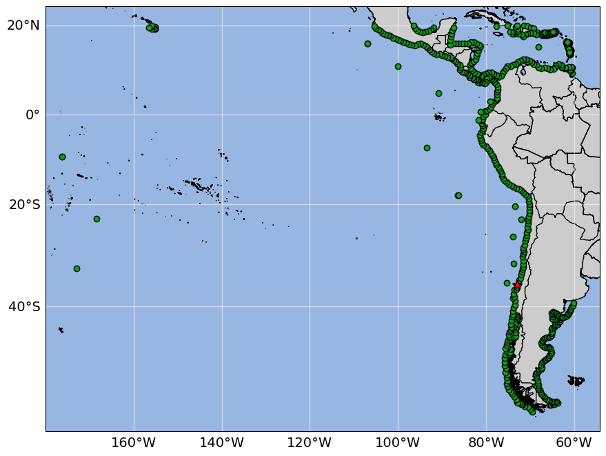

```python
pois = np.load(os.path.join(input_folder, 'pois_fixed.npy'), allow_pickle=True).item()
n_pois = len(pois['pois_coords'])
print(f'Total number of POIs: {n_pois}')

pois_coords = pois['pois_coords']
pois_index = np.arange(n_pois)
plot_pois(pois_coords, pois_index, event_dict)
```

**STEP1 - define the ensemble of scenarios**

(PTF global version)

```python
print('Creating discretized ensemble')
ensemble = dict()

# discretized magnitude
ensemble['magnitude'], ensemble['magnitude_idx'] = select_magnitude(event_dict, magnitude_values, sigma)

# discretized positions in geographic coordinates
location_ellipse_2d = build_location_ellipsoid_objects(event           = event_dict,
                                                       sigma           = sigma,
                                                       seismicity_type = 'BS')

position_step = 25000.
utm_x, utm_y = discretized_position(location_ellipse_2d, position_step)

ensemble['position_utm_x'] = utm_x
ensemble['position_utm_y'] = utm_y

# discretized depth in km
tmp = load_lambda_BSPS(sigma, event_dict)

ellipsoid_3d = tmp['gaussian_ellipsoid']

depth_step = 5000.
ensemble['depth'] = discretized_depth(-ellipsoid_3d['zp'], depth_step)

grid_3d, lon, lat = create_grid3d(event_dict, ensemble)

# fix for negative longitudes
lon[lon<0] += 360.

ensemble['grid_3d'] = grid_3d
ensemble['position_geo_lon'] = lon
ensemble['position_geo_lat'] = lat

# focal mechanism for Maule 2010 from USGS (https://earthquake.usgs.gov/earthquakes/eventpage/official20100227063411530_30/moment-tensor)
focal_mechanism = {'np1': {'strike': 178.0, 'dip': 77.0, 'rake': 86.0},
                   'np2': {'strike': 17.0, 'dip': 14.0, 'rake': 108.0}}

strike_step = 15.0
strike_sigma = 15.0
dip_step = 12.0
dip_sigma = 12.0
rake_step = 15.0
rake_sigma = 15.0

ensemble['focal_mechanism'] = discretized_mechanism(focal_mechanism, strike_step, strike_sigma, dip_step, dip_sigma,
                                                    rake_step, rake_sigma)

ensemble['fault_size'] = compute_fault_size(ensemble['magnitude'])

ensemble['slip'] = compute_slip(ensemble['magnitude'], ensemble['fault_size'], rigidity)


print('--> Computing probabilities')
ensemble_probs = dict()
ensemble_probs['magnitude'] = compute_mag_probability(ensemble['magnitude_idx'], event_dict, magnitude_values)

ensemble_probs['position'] = compute_pos_probability(event_dict, ensemble)

ensemble_probs['focal_mechanism'] = compute_mech_probability(ensemble = ensemble)

# creation of scenarios parameters list and computing corresponding probabilities
scen_params, scen_probs = scenarios_parameters_and_probabilities(ensemble_probs, ensemble)

scenarios = dict()
scenarios['par_scenarios_sbs'] = scen_params
scenarios['ProbScenSBS'] = scen_probs
```

```
Creating discretized ensemble
--> Selecting magnitude values
    Number of magnitude values = 3
    Magnitudes selected: [8.7118 8.8025 8.8846]
--> Discretizing positions
    Number of points along x= 6
    Number of points along y= 6
 --> Volume of the Gaussian Ellipsoid: 1.58636168e+12 [m^3]
 --> N. Tetra in the Gaussian Ellipsoid: 273
 --> Volume of Tetra in the Gaussian Ellipsoid: 1.44770769e+12 [m^3]
 --> Volume difference Gaussian <--> Tetra: 8.74 [%]
--> Discretizing depths
    Number of points along z= 5
--> Creating grid 3d
    Number of grid points = 180
--> Discretizing strike, dip, and rake values
    Number of angle combinations = 54
--> Computing fault size
--> Computing slip
--> Computing probabilities
--> Computing magnitude cumulative distribution
--> Computing position probabilities
--> Computing focal mechanism probabilities
--> Computing the total probability for each scenario
Total number of scenarios = 29160
```

```python
# saving scenario lists (parameters and probabilities)
file_sbs_list = os.path.join(output_folder, 'step1_SBS_scenarios_list.txt')
file_sbs_prob = os.path.join(output_folder, 'step1_SBS_scenarios_prob.npy')

par_scenarios_sbs = scenarios['par_scenarios_sbs']
len_scenarios_sbs, len_pars = par_scenarios_sbs.shape

fmt = "{:f}".format
with open(file_sbs_list, 'w') as f_list_bs:
    for ic in range(len_scenarios_sbs):
        pars = " ".join(fmt(par_scenarios_sbs[ic, item]) for item in range(2, len_pars))
        # pars = " ".join(fmt(par_scenarios_sbs[ic, item]) for item in range(1, len_pars))
        ireg = "{:.0f}".format(par_scenarios_sbs[ic, 1])
        f_list_bs.write("{:s} {:s} {:s}\n".format(str(ic+1), ireg, pars))
        # f_list_bs.write("{:s} {:s}\n".format(str(ic+1), pars))

prob_scenarios_sbs = scenarios['ProbScenSBS']
np.save(file_sbs_prob, prob_scenarios_sbs)

print('SBS scenarios saved in: {}'.format(file_sbs_list))
print('SBS probabilities saved in: {}'.format(file_sbs_prob))
```

```
SBS scenarios saved in: output/step1_SBS_scenarios_list.txt
SBS probabilities saved in: output/step1_SBS_scenarios_prob.npy
```

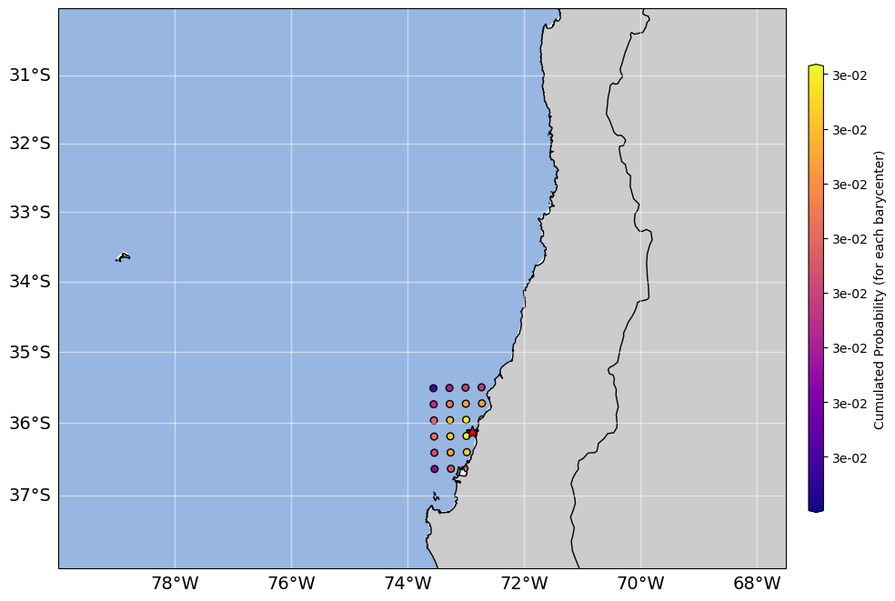

```python
# plot scenarios
plot_barycenters(par_scenarios_sbs[:,3:5], prob_scenarios_sbs, event_dict)
```

**STEP 2 - Scenario modeling**

Step 2 is not going to be executed in this notebook, since the tsunami simulations are already done and stored in the SDL (https://sdl.hpc.cineca.it). The final output of this step (nc file including the maximum wave height from each scenario at each POI) is assumed to be produced in the output folder and will be loaded for the further steps

```python
file_hmax_sim_sbs = os.path.join(output_folder, 'step2_hmax_sim_SBS.nc')
imax_scenarios_sbs = h5py.File(file_hmax_sim_sbs, 'r')
mih_sbs = np.array(imax_scenarios_sbs['ts_p2t_gl'])
```

**STEP3 - Hazard aggregation**

```python
print('Computing hazard curves from SBS scenarios')
# The execution of this cell requires a few minutes (<10 min).
# A different optimized strategy is implemented in the original PTF code, but it is not applicable here due to memory issues.
hc_pois_sbs = compute_hazard_curves(mih_sbs, prob_scenarios_sbs, n_pois, thresholds, sigma)
```

```
Computing hazard curves from SBS scenarios
```

```python
hc_pois = hc_pois_sbs

list_percentiles = [50, 15, 10, 5, 1]
percentiles = np.array(list_percentiles) * 0.01
n_percentiles = len(percentiles)
mih_percentiles = np.zeros((n_pois, n_percentiles))

for i in range(n_pois):
    mih_percentiles[i,:] = np.interp(percentiles, hc_pois[i,::-1], thresholds[::-1])

hc_d = dict()
hc_d['mean'] = scipy.integrate.simpson(hc_pois, thresholds)

# percentiles' labels are expressed as 1-p since they represent the survival function (not exceedance)
for ip, percentile in enumerate(percentiles):
    if percentile == 0:
        print('Percentile 100 is not allowed.')
    elif percentile != 0.0001:
        hc_d['p' +  '{:.0f}'.format((1-percentile)*100).zfill(2)] = mih_percentiles[:,ip]
    else:
        hc_d['envelope'] = mih_percentiles[:,ip]
```

```python
#saving hazard curves and percentiles
file_hc_pois = os.path.join(output_folder, 'step3_hazard_curves.npz')
file_percentiles = os.path.join(output_folder, 'step3_hazard_curves_percentiles.npy')

hazard_curves_pois_sparse = scipy.sparse.csr_matrix(hc_pois.astype(np.float32))
scipy.sparse.save_npz(file_hc_pois, hazard_curves_pois_sparse)
np.save(file_percentiles, hc_d, allow_pickle=True)
```

**STEP5 - Plotting**

```
Plotting hazard maps
mapping ... mean
mapping ... p50
mapping ... p85
mapping ... p90
mapping ... p95
mapping ... p99
```

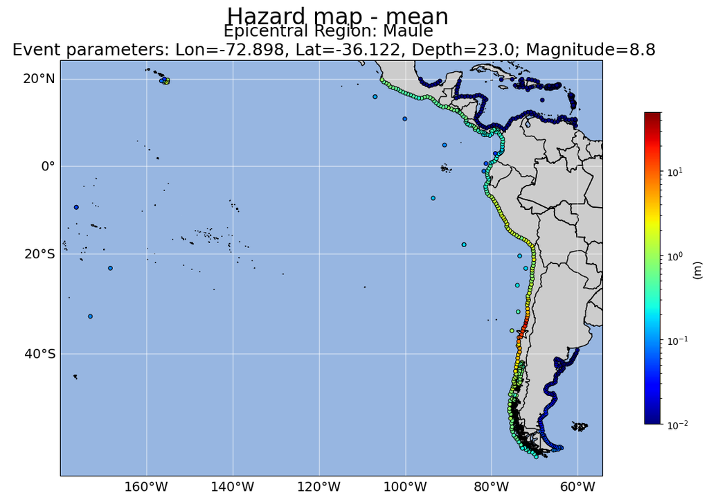

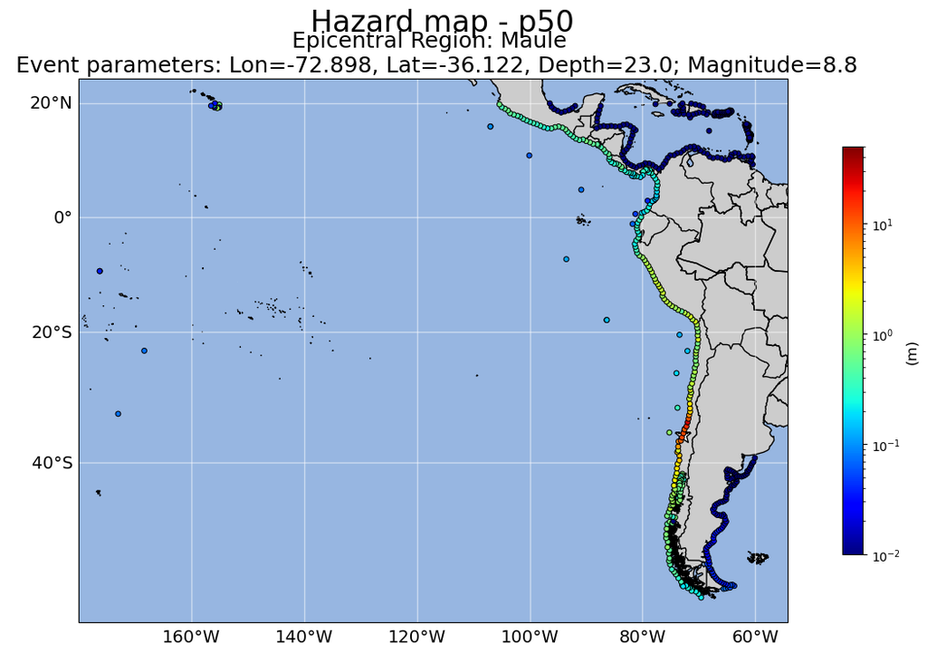

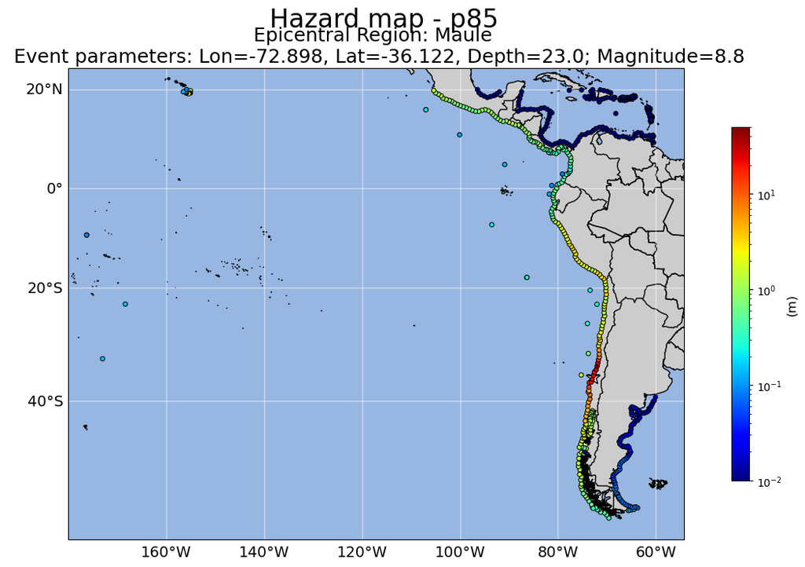

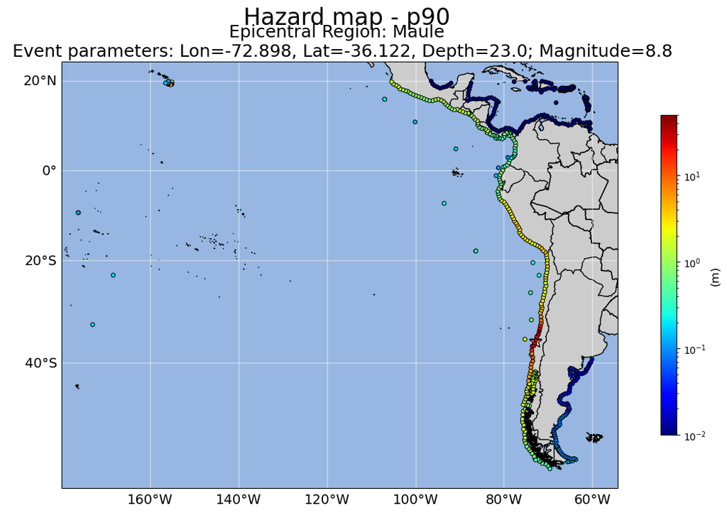

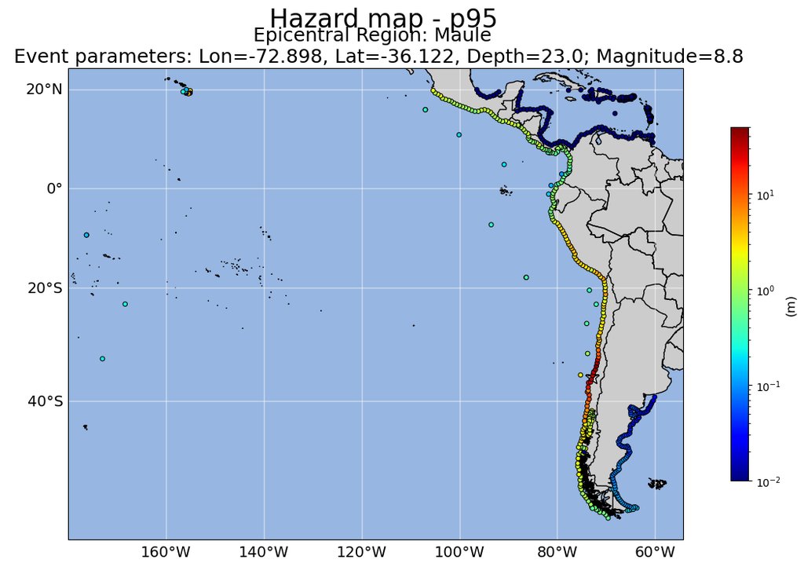

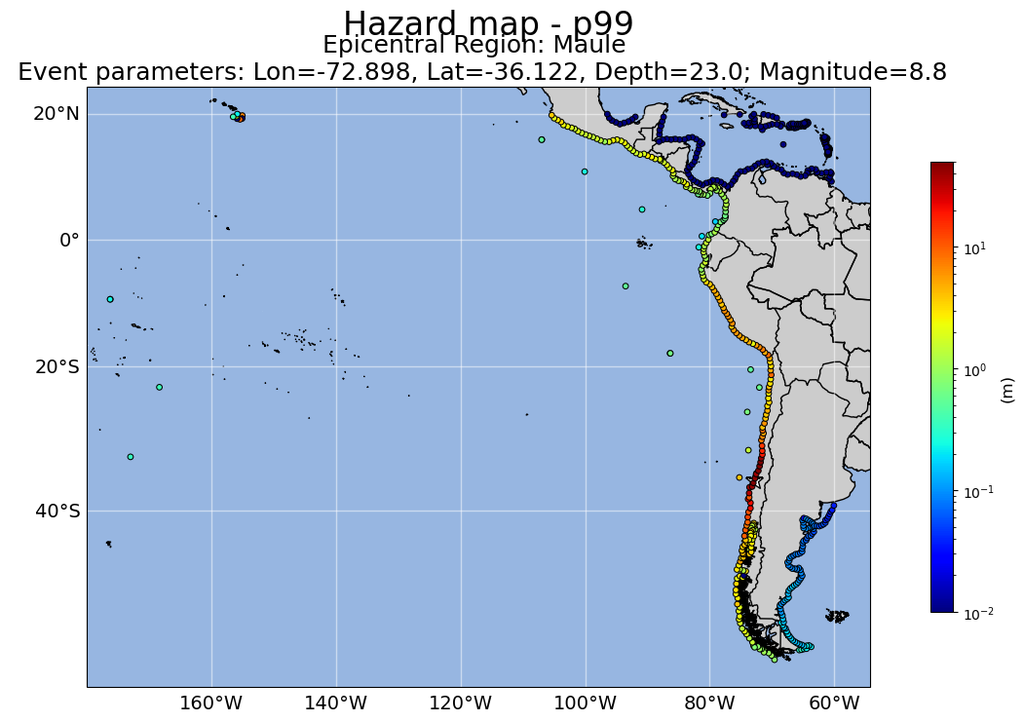

```python
# hazard maps
print('Plotting hazard maps')
plot_hazard_maps(pois_coords, hc_d, event_dict, "HazMap")
```

**Data comparison**

[figure not shown]

**Data Assimilation**

```python
print('Executing scenario player to retrieve data for the event')

sealevel_dict = run_scenario_player(event_dict, data_folder)
# ngauges = len(sealevel_dict.keys())

# alternative to rge scenario player, to use only DART data
# sealevel_dict = dict()
# coords_file = os.path.join(input_folder,'use_dart_only/coordinates_dart.dat')
# with open(coords_file, 'r') as f:
#     next(f)
#     for line in f:
#         # print(line.strip())
#         name = line.split(' ')[0]
#         lon = float(line.split(' ')[2])
#         lat = float(line.split(' ')[3])
#         sealevel_dict[name] = dict()
#         sealevel_dict[name]['coords'] = (lat, lon)
#         data_filename = os.path.join(input_folder,'use_dart_only/' + name + '_res_min_m.dat')
#         datatmp = np.loadtxt(data_filename)
#         datatmp = datatmp[datatmp[:,0] >= 0]
#         df = pd.DataFrame({"sec": datatmp[:,0]*60., "sea_level": datatmp[:,1]})
#         sealevel_dict[name]['data'] = df
# # print(sealevel_dict)
```

```
Executing scenario player to retrieve data for the event
Number of SLD stations within 5000.0 km: 193
error:  0
Stations without data available: 178
Stations with data available: 15
  ssc_id: ancu, name: Ancud
  ssc_id: anto, name: Antofagasta
  ssc_id: aric, name: Arica
  ssc_id: cald, name: Caldera
  ssc_id: call, name: Callao, La Punta
  ssc_id: coqu, name: Coquimbo
  ssc_id: corr, name: Corral
  ssc_id: dper, name: DART Lima
  ssc_id: iqui, name: Iquique
  ssc_id: juan, name: Juan Fernandez
  ssc_id: pcha, name: Puerto_Chacabuco
  ssc_id: pmon, name: Puerto Montt
  ssc_id: sanf, name: San Felix
  ssc_id: stan, name: Stanley
  ssc_id: talc, name: Talcahuano
```

```
Finding closest POIs to each gauge
Gauge Ancud (-73.83,-41.87): POI 382 (286.09,-41.40)
Gauge Antofagasta (-70.40,-23.65): POI 415 (289.47,-23.54)
Gauge Arica (-70.32,-18.48): POI 423 (289.63,-18.74)
Gauge Caldera (-70.82,-27.06): POI 409 (289.07,-27.10)
Gauge Callao, La Punta (-77.17,-12.07): POI 440 (282.73,-11.81)
Gauge Coquimbo (-71.34,-29.95): POI 404 (288.63,-29.76)
Gauge Corral (-73.43,-39.89): POI 385 (286.53,-39.68)
Gauge DART Lima (-86.39,-17.98): POI 555 (273.63,-17.98)
Gauge Iquique (-70.15,-20.20): POI 421 (289.83,-19.93)
Gauge Juan Fernandez (-78.83,-33.62): POI 547 (284.76,-35.76)
Gauge Puerto_Chacabuco (-72.82,-45.47): POI 361 (286.67,-44.90)
Gauge Puerto Montt (-72.97,-41.48): POI 369 (287.07,-41.50)
Gauge San Felix (-80.12,-26.26): POI 450 (279.43,-6.77)
Gauge Stanley (-57.93,-51.75): POI 5 (296.28,-54.70)
Gauge Talcahuano (-73.11,-36.70): POI 391 (286.81,-36.93)
```

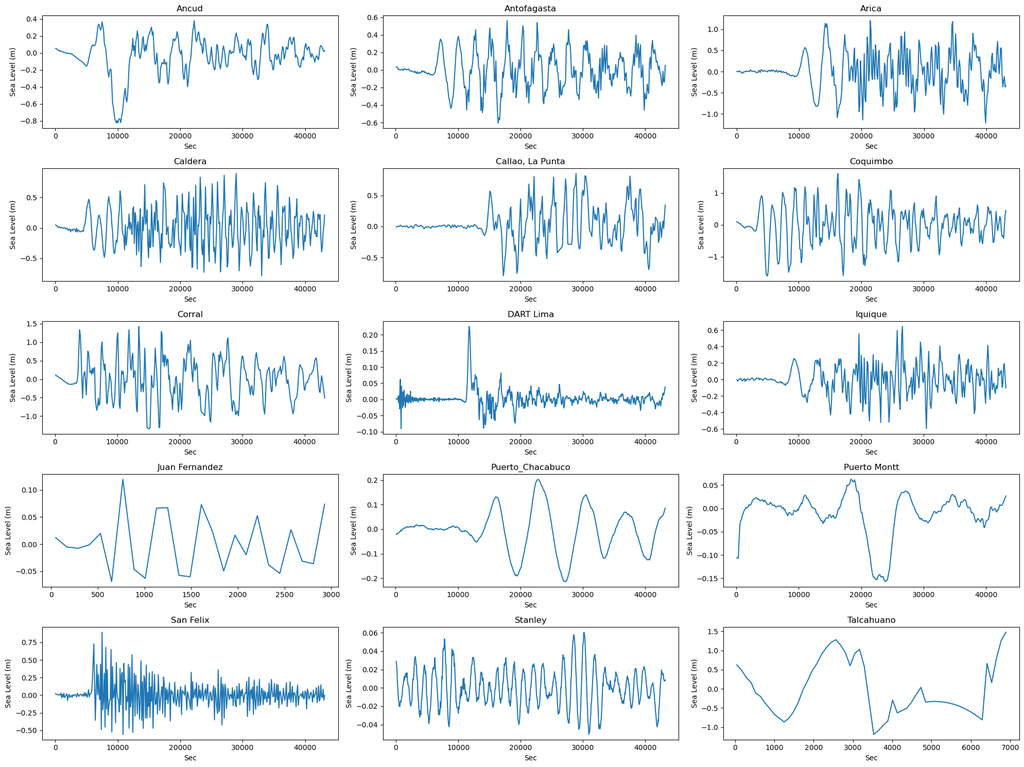

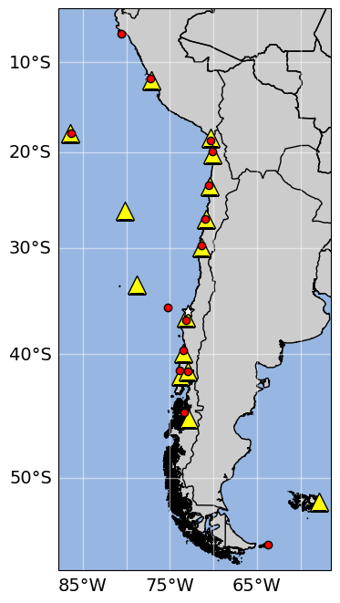

```python
plot_sealevel(sealevel_dict)
# Search for the closest POIs to the sea level stations
pois_d = np.load(os.path.join(input_folder, 'pois.npy'), allow_pickle=True).item() #tsunami simulations were performed with a non-sanitized POIs file
gauge_pois = find_closest_pois(sealevel_dict, pois_d, event_dict)
```

```
Finding closest POIs to each gauge
Gauge Ancud (-73.83,-41.87): POI 382 (286.09,-41.40)
Gauge Antofagasta (-70.40,-23.65): POI 415 (289.47,-23.54)
Gauge Arica (-70.32,-18.48): POI 423 (289.63,-18.74)
Gauge Caldera (-70.82,-27.06): POI 409 (289.07,-27.10)
Gauge Callao, La Punta (-77.17,-12.07): POI 440 (282.73,-11.81)
Gauge Coquimbo (-71.34,-29.95): POI 404 (288.63,-29.76)
Gauge Corral (-73.43,-39.89): POI 385 (286.53,-39.68)
Gauge DART Lima (-86.39,-17.98): POI 555 (273.63,-17.98)
Gauge Iquique (-70.15,-20.20): POI 421 (289.83,-19.93)
Gauge Talcahuano (-73.11,-36.70): POI 391 (286.81,-36.93)
```

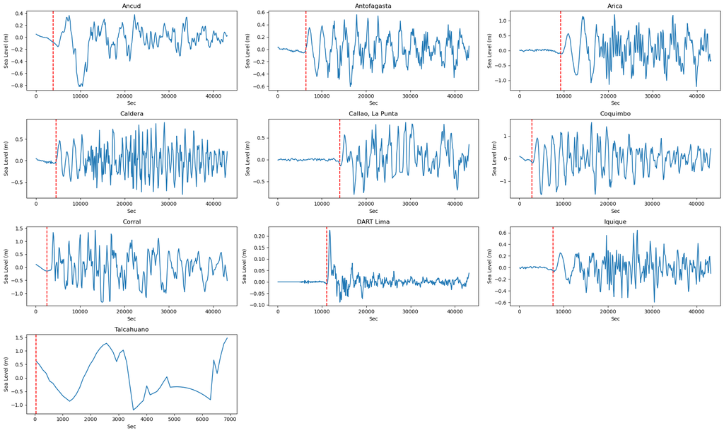

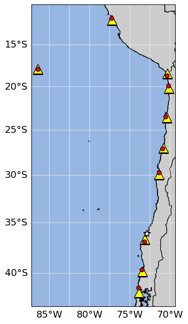

```python
# The quality control of the sea level data is not automatized yet, so some manual checks are required.

# From DART Lima (32412) the surface Rayleigh waves at the beginning of the ts must be zeroed (otherwise the picked arrival time will be wrong)
df = sealevel_dict['DART Lima']['data']
# df = sealevel_dict['DART_32412']['data']
df.loc[df['sec'] <= 5000, 'sea_level'] = 0
sealevel_dict['DART Lima']['data'] = df
# sealevel_dict['DART_32412']['data'] = df

# df = sealevel_dict['DART_32411']['data']
# df.loc[df['sec'] <= 5000, 'sea_level'] = 0
# df = df[df['sec'] <= 60000]
# sealevel_dict['DART_32411']['data'] = df
#
# # remove spikes
# df = sealevel_dict['DART_51425']['data']
# # df.loc[df['sea_level'] > 0.09, 'sea_level'] = 0.
# df.loc[(df['sec'] < 60000) & (df['sea_level'] > 0.025), 'sea_level'] = 0
# sealevel_dict['DART_51425']['data'] = df
# df = sealevel_dict['DART_51426']['data']
# df.loc[df['sec'] <= 41000, 'sea_level'] = 0
# sealevel_dict['DART_51426']['data'] = df

# Some stations are removed from the dictionary because they do not show a tsunami signal or do not have the corresponding POI.
stat_to_remove = ['Puerto Montt', 'Puerto_Chacabuco', 'Stanley', 'Juan Fernandez', 'San Felix']
# stat_to_remove = ['DART_51406']
for stat in stat_to_remove:
    sealevel_dict.pop(stat, None)

arrival_times = pick_arrival_times(sealevel_dict)

plot_sealevel(sealevel_dict, arrival_times)
gauge_pois = find_closest_pois(sealevel_dict, pois_d, event_dict)

np.save(os.path.join(sea_level_folder, 'sealevel_data.npy'), sealevel_dict, allow_pickle=True)
np.save(os.path.join(sea_level_folder, 'sealevel_gauge_pois.npy'), gauge_pois)
```

The misfit evaluator is supposed to be already executed as it requires the tsunami time series from all the simulations. Here, the output is uploaded.

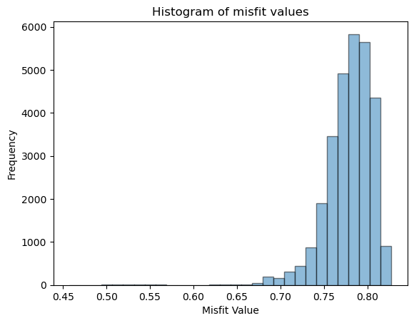

```python
misfit_values = np.loadtxt(os.path.join(output_folder, 'total_misfit.txt'))
plot_histogram_misfit(misfit_values)
```